# Lab #2: Classification in R

Ntemena Kapula

The purpose of this lab is to get you familiar with fitting classification models in R.

## Simulating data:

1. Simulate a multivariate (3 variables) predictor with 3 classes using the following.

```r
nsamp <- 100
SMat <- matrix(c(1.0, 0.6, 0.3, 0.4, 1.0, 0.7, 0.1, 0.1, 1.0), nrow=3, ncol=3)
datmat1 <- mvrnorm(n = nsamp, mu = rep(-1.0, 3), Sigma = SMat)
datmat2 <- mvrnorm(n = nsamp, mu = rep(1.0, 3), Sigma = SMat)
datmat3 <- mvrnorm(n = nsamp, mu = c(0.0,0.5,-1.0), Sigma = SMat)
```

2. Stack `datamat1`, `datamat2`, and `datamat3` to generate a single 300x3 matrix called datamat.

```r
datamat <- rbind(datmat1, datmat2, datmat3)
dim(datamat)
```

```
## [1] 300   3
```

3. Generate a groups factor such that the first 100 data points are labeled `outcome1`, the second 100 `outcome2`, and the third 100 `outcome3`.

```r
groups <- factor(c(rep("outcome1", nsamp), rep("outcome2", nsamp), rep("outcome3", nsamp)))
```

4. Combine groups and datamat into a data frame called `dat`. Give the dataframe column names `groups`, `predictor1`, `predictor2`, `predictor3`.

```r
dat <- data.frame(
  groups=groups,
  datamat
)

names(dat) <- c("groups", "predictor1", "predictor2", "predictor3")
```

5. Make pairwise plots of the predictors in the data using the command `pairs`.

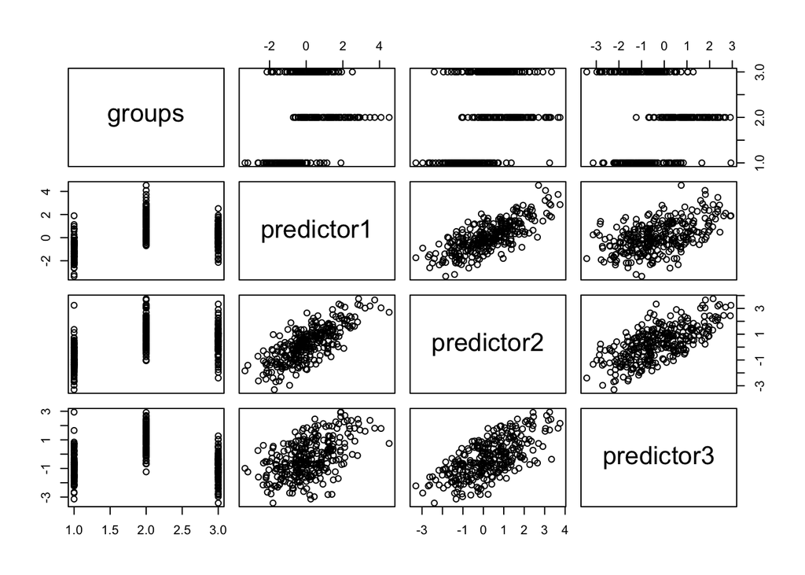

```r
pairs(dat)
```

6. Re-do the scatterplot so that get each data-point is color coded by groups using the `col` argument.

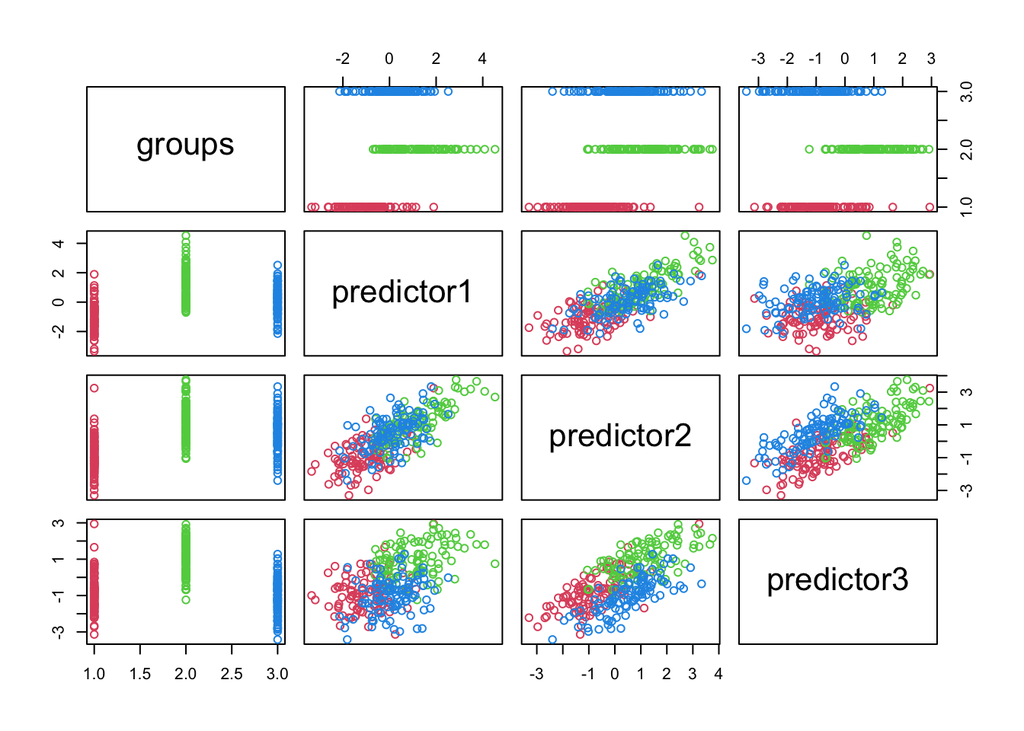

```r
pairs(dat, col=1+as.numeric(dat$groups))
```

7. Use it to plot the data in 3D using `scatterplot3d`. Color-code the points by group.

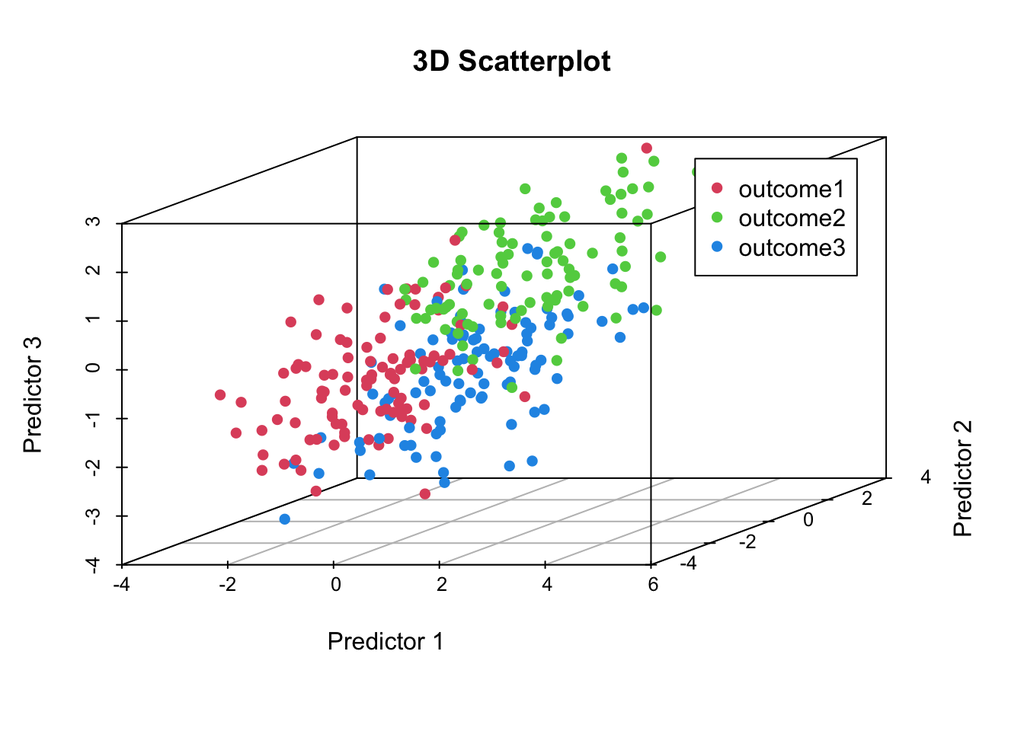

```r
s3d <- scatterplot3d(dat$predictor1, dat$predictor2, dat$predictor3, xlab="Predictor 1", ylab="Predictor 2", zlab="Predictor 3", pch=16, color=1+as.numeric(dat$groups), main="3D Scatterplot")

legend(s3d$xyz.convert(3.5, 2,3), levels(dat$groups), col = 2:4, pch=16)
```

8. Simulate a new set of test data (call it `test_dat`) with the same settings and the same number of observations. Use `set.seed(15)` instead.

```r
set.seed(15)

nsamp <- 100
SMat <- matrix(c(1.0, 0.6, 0.3, 0.4, 1.0, 0.7, 0.1, 0.1, 1.0), nrow=3, ncol=3)
datmat1b <- mvrnorm(n = nsamp, mu = rep(-1.0, 3), Sigma = SMat)
datmat2b <- mvrnorm(n = nsamp, mu = rep(1.0, 3), Sigma = SMat)
datmat3b <- mvrnorm(n = nsamp, mu = c(0.0,0.5,-1.0), Sigma = SMat)

datmatb <- rbind(datmat1b, datmat2b, datmat3b)
test_dat <- data.frame(groups, datmatb)
names(test_dat) <- c("groups", "predictor1", "predictor2", "predictor3")
```